# HW2

Kathleen Cimino

3/21/2022

The data is contained in a data frame with 397 observations on the following 6 variables: • Rank - a factor with levels AssocProf AsstProf Prof • Discipline - a factor with levels A (“theoretical” departments) or B (“applied” departments). • yrs.since.phd - years since PhD. • yrs.service- years of service. • Sex - a factor with levels Female Male • Salary - nine-month salary, in dollars.

1. Load the dataset from the file prof_salary.Rdata. Since the file is already in R format, use the load( ) function. Do NOT use the dataset from the carData package!

```r
load("prof_salary.Rdata")
```

2. What is the percentage of missing data in each variable?

```r
contents(prof_salary)
```

```
##
## The data frame prof_salary has 397 observations and 6 variables.
##
## Overall
##  pos varname       type    n_unique n_miss pct_miss
##  1   rank          factor    3       0     0%
##  2   discipline    factor    2       0     0%
##  3   yrs.since.phd integer  53       0     0%
##  4   yrs.service   integer  45      53     13%
##  5   sex           factor    2       0     0%
##  6   salary        integer 347      26     7%
##
## Numeric Variables
##                 n      mean       sd skew   min     p25   median      p75
## yrs.since.phd 397     22.31    12.89 0.30     1    12.0     21.0     32.0
## yrs.service   344     15.20    11.56 0.76     0     6.0     12.5     23.0
## salary        371 112108.86 29113.87 0.72 62884 90259.5 106608.0 132130.5
##                  max
## yrs.since.phd     56
## yrs.service       49
## salary        231545
##
## Categorical Variables
##  variable   level     n   pct
##  rank       AsstProf   67 0.17
##             AssocProf  64 0.16
##             Prof      266 0.67
##  discipline A         181 0.46
##             B         216 0.54
##  sex        Female     39 0.10
##             Male      358 0.90
```

Salary is missing 7 percent; yrs.service is missing 13 percent; and rank, sex, discipline, and yrs.since.phd are not missing any data.

3. What are the patterns of missing data? Create two plots: one using the md.pattern function and one using the aggr function. Interpret the results in words.

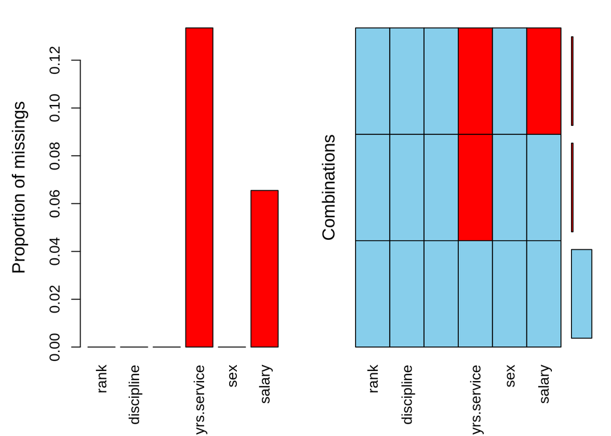

```r
library(VIM)
aggr(prof_salary)
```

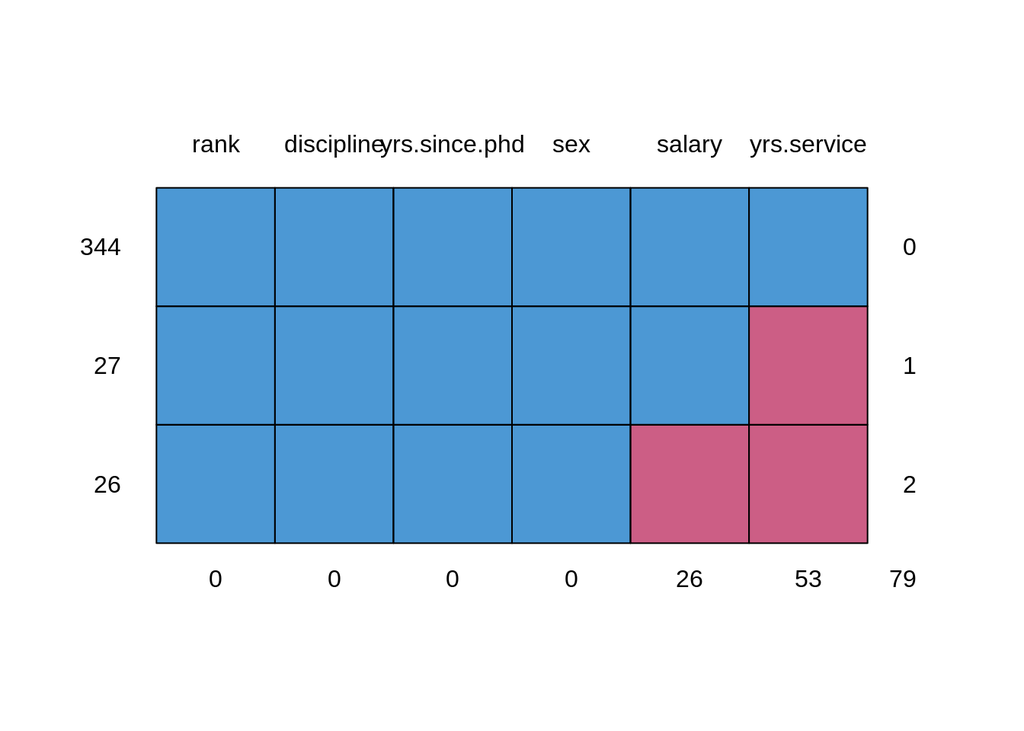

```
##     rank discipline yrs.since.phd sex salary yrs.service
## 344    1          1             1   1      1           1  0
## 27     1          1             1   1      1           0  1
## 26     1          1             1   1      0           0  2
##        0          0             0   0     26          53 79
```

```r
library(mice)
md.pattern(prof_salary)
```

Years of service can be missing either on its own or with salary, while salary is only missing when years of service is also missing.

4. Is there a relationship between missing values on salary and missing values on years of service? To answer this, replace the two original variables with indicator variables (1=missing, 0=present) and calculate the Pearson correlation between these indicator variables. Interpret the results.

```r
prof_salary.missing <- prof_salary %>%
  mutate(
    salary.missing = ifelse(is.na(salary),1,0),
    yrs.service.missing = ifelse(is.na(yrs.service),1,0)
                                      )
cor.test(prof_salary.missing$salary.missing, prof_salary.missing$yrs.service.missing)
```

```
##
##  Pearson's product-moment correlation
##
## data:  prof_salary.missing$salary.missing and prof_salary.missing$yrs.service.missing
## t = 18.155, df = 395, p-value < 2.2e-16
## alternative hypothesis: true correlation is not equal to 0
## 95 percent confidence interval:
##  0.6169684 0.7247499
## sample estimates:
##       cor
## 0.6744364
```

```r
rm(prof_salary.missing)
```

There is a statistically significant relationship between the missing salary variable and missing years of service variable (t= 18.16, p-value < .001). This indicates that the data is likely not Missing Completely At Random and therefore it would be best to not use list-wise deletion.

5. Perform a linear regression predicting salary from the other five variables. Use list-wise deletion. What percentage of the observations are lost using listwise deletion?

```r
prof_salary.ld <- na.omit(prof_salary)
nrow(na.omit(prof_salary))/nrow(prof_salary)
```

```
## [1] 0.8664987
```

```r
lm1 <- lm(salary ~ ., data = prof_salary.ld)
summary(lm1)
```

```
##
## Call:
## lm(formula = salary ~ ., data = prof_salary.ld)
##
## Residuals:
##    Min     1Q Median     3Q    Max
## -66155 -11855  -1098   9693  82357
##
## Coefficients:
##               Estimate Std. Error t value Pr(>|t|)
## (Intercept)    65953.6     4047.0  16.297  < 2e-16 ***
## rankAssocProf  13245.8     3629.9   3.649 0.000305 ***
## rankProf       44564.6     3845.4  11.589  < 2e-16 ***
## disciplineB    16525.9     2171.9   7.609 2.79e-13 ***
## yrs.since.phd    312.3      246.1   1.269 0.205320
## yrs.service     -257.0      217.2  -1.183 0.237574
## sexMale         3866.7     3326.3   1.162 0.245870
## ---
## Signif. codes:  0 '***' 0.001 '**' 0.01 '*' 0.05 '.' 0.1 ' ' 1
##
## Residual standard error: 19360 on 337 degrees of freedom
## Multiple R-squared:  0.5393, Adjusted R-squared:  0.5311
## F-statistic: 65.75 on 6 and 337 DF,  p-value: < 2.2e-16
```

```r
rm(prof_salary.ld)
```

13.4% of the observations are lost after performing list-wise deletion. Compared to assistant professors, associate professors earn 13245.8 more and this difference is statistically significant (t= 3.65, p-value < .001) and professors earn 44564.6 more and this difference is also statistically significant (t= 11.59, p-value < .001). People in applied departments earn 16525.9 more and this difference is statistically significant (t = 7.61, p-value < .001). Sex, years since phd, and years of service are not statistically significant.

6. Perform a linear regression predicting salary from the five other variables. Use kNN to impute missing values. Use the imp_var=FALSE option to avoid creating additional variables. Describe your findings.

```r
prof_salary.knn <- kNN(prof_salary, imp_var=FALSE)

lm2 <- lm(salary ~ ., data = prof_salary.knn)
summary(lm2)
```

```
##
## Call:
## lm(formula = salary ~ ., data = prof_salary.knn)
##
## Residuals:
##    Min     1Q Median     3Q    Max
## -64912 -13050  -1215  10510  98329
##
## Coefficients:
##               Estimate Std. Error t value Pr(>|t|)
## (Intercept)    67345.7     4226.2  15.935  < 2e-16 ***
## rankAssocProf  13508.6     3851.0   3.508 0.000504 ***
## rankProf       45724.5     3918.4  11.669  < 2e-16 ***
## disciplineB    14689.9     2169.5   6.771 4.71e-11 ***
## yrs.since.phd    215.5      206.7   1.043 0.297715
## yrs.service     -205.8      205.2  -1.003 0.316535
## sexMale         4056.6     3582.7   1.132 0.258219
## ---
## Signif. codes:  0 '***' 0.001 '**' 0.01 '*' 0.05 '.' 0.1 ' ' 1
##
## Residual standard error: 20940 on 390 degrees of freedom
## Multiple R-squared:  0.4806, Adjusted R-squared:  0.4727
## F-statistic: 60.15 on 6 and 390 DF,  p-value: < 2.2e-16
```

```r
rm(prof_salary.knn)
```

Compared to assistant professors, associate professors earn 13508.6 more and this difference is statistically significant (t= 3.51, p-value < .001) and professors earn 45724.5 more and this difference is also statistically significant (t= 11.67, p-value < .001). People in applied departments earn 14689.9 more and this difference is statistically significant (t = 6.77, p-value < .001). Sex, years since phd, and years of service are not statistically significant.

7. It turns out in speaking with the researchers, that men with many years of experience were less likely to answer the salary question. What missing data mechanism does this describe (MCAR, MAR, NMAR)? Justify your answer.

This missing data mechanism describes Missing At Random. This is because the missingness of the data can be explained by other variables within the data set (i.e. because the missingness of the salary question can be explained by the years of service variable).

8. Discuss under what circumstances you would use listwise deletion vs. kNN imputation to deal with missing data

KNN tends to work well when data is MCAR or MAR, but it can be computationally expensive. List-wise deletion can be useful for MCAR data because it returns a random sample of the initial sample, especially if KNN would be too computationally expensive and there would be a reasonable amount of data after list-wise deletion.